# Descripción del Proyecto

El proyecto consistirá en preparar el prototipo de un modelo de machine learning para Zyfra. La empresa desarrolla soluciones de eficiencia para la industria pesada. El modelo deberá predecir la cantidad de oro extraído del mineral de oro. Disponemos de los datos de extracción y purificación.

Los datos se almacenan en tres archivos:

- `gold_recovery_train.csv` — el dataset de entrenamiento
- `gold_recovery_test.csv` —el dataset de prueba
- `gold_recovery_full.csv` — el dataset fuente

Los datos se indexan con la fecha y la hora de adquisición (date). Los parámetros cercanos en el tiempo suelen ser similares. Algunos parámetros no están disponibles porque fueron medidos o calculados mucho más tarde. Por eso, algunas de las características que están presentes en el conjunto de entrenamiento pueden estar ausentes en el conjunto de prueba. El conjunto de prueba tampoco contiene objetivos. El dataset fuente contiene los conjuntos de entrenamiento y prueba con todas las características.

# Tabla de Contenidos

## Inicialización

```python
# Cargamos todas las librerías a usar
import pandas as pd
from IPython.display import display, HTML, Image
import matplotlib.pyplot as plt
import numpy as np

#from sklearn.model_selection import train_test_split
#from sklearn.metrics import mean_absolute_error

from sklearn.tree import DecisionTreeRegressor
from sklearn.ensemble import RandomForestRegressor
from sklearn.linear_model import LinearRegression

from sklearn.model_selection import GridSearchCV
from sklearn.metrics import make_scorer

from sklearn.model_selection import cross_val_score

pd.set_option('display.max_rows', None)
pd.set_option('display.max_columns', None)
```

```python
#Definimos una función Print que sea visualmente mas amigable
def print_mejorado(texto,size):
    size=str(size)
    display(HTML('<span style="font-size: '+size+'px;">'+texto+'</span>'))
```

## Cargar los datos

```python
data_train=pd.read_csv('/datasets/gold_recovery_train.csv')
data_test=pd.read_csv('/datasets/gold_recovery_test.csv')
data_full=pd.read_csv('/datasets/gold_recovery_full.csv')
```

### Dataset de entrenamiento (data_train)

```python
data_train.head()
```

|  | date | final.output.concentrate_ag | final.output.concentrate_pb | final.output.concentrate_sol | final.output.concentrate_au | final.output.recovery | final.output.tail_ag | final.output.tail_pb | final.output.tail_sol | final.output.tail_au | primary_cleaner.input.sulfate | primary_cleaner.input.depressant | primary_cleaner.input.feed_size | primary_cleaner.input.xanthate | primary_cleaner.output.concentrate_ag | primary_cleaner.output.concentrate_pb | primary_cleaner.output.concentrate_sol | primary_cleaner.output.concentrate_au | primary_cleaner.output.tail_ag | primary_cleaner.output.tail_pb | primary_cleaner.output.tail_sol | primary_cleaner.output.tail_au | primary_cleaner.state.floatbank8_a_air | primary_cleaner.state.floatbank8_a_level | primary_cleaner.state.floatbank8_b_air | primary_cleaner.state.floatbank8_b_level | primary_cleaner.state.floatbank8_c_air | primary_cleaner.state.floatbank8_c_level | primary_cleaner.state.floatbank8_d_air | … |
| --- | --- | --- | --- | --- | --- | --- | --- | --- | --- | --- | --- | --- | --- | --- | --- | --- | --- | --- | --- | --- | --- | --- | --- | --- | --- | --- | --- | --- | --- | --- |
| 0 | 2016-01-15 00:00:00 | 6.055403 | 9.889648 | 5.507324 | 42.192020 | 70.541216 | 10.411962 | 0.895447 | 16.904297 | 2.143149 | 127.092003 | 10.128295 | 7.25 | 0.988759 | 8.547551 | 10.389648 | 19.529297 | 34.174427 | 14.936526 | 2.534912 | 7.476074 | 2.106679 | 1549.775757 | -498.912140 | 1551.434204 | -516.403442 | 1549.873901 | -498.666595 | 1554.367432 | … |
| 1 | 2016-01-15 01:00:00 | 6.029369 | 9.968944 | 5.257781 | 42.701629 | 69.266198 | 10.462676 | 0.927452 | 16.634514 | 2.224930 | 125.629232 | 10.296251 | 7.25 | 1.002663 | 8.558743 | 10.497069 | 19.369147 | 34.118526 | 16.250511 | 3.049646 | 6.733907 | 2.353017 | 1576.166671 | -500.904965 | 1575.950626 | -499.865889 | 1575.994189 | -499.315107 | 1574.479259 | … |
| 2 | 2016-01-15 02:00:00 | 6.055926 | 10.213995 | 5.383759 | 42.657501 | 68.116445 | 10.507046 | 0.953716 | 16.208849 | 2.257889 | 123.819808 | 11.316280 | 7.25 | 0.991265 | 8.603505 | 10.354494 | 19.167579 | 33.969464 | 16.491823 | 3.124664 | 6.471768 | 2.416800 | 1601.556163 | -499.997791 | 1600.386685 | -500.607762 | 1602.003542 | -500.870069 | 1599.541515 | … |
| 3 | 2016-01-15 03:00:00 | 6.047977 | 9.977019 | 4.858634 | 42.689819 | 68.347543 | 10.422762 | 0.883763 | 16.532835 | 2.146849 | 122.270188 | 11.322140 | 7.25 | 0.996739 | 7.221879 | 8.496563 | 15.978538 | 28.260743 | 16.024359 | 2.960362 | 6.843791 | 2.262051 | 1599.968720 | -500.951778 | 1600.659236 | -499.677094 | 1600.304144 | -500.727997 | 1600.449520 | … |
| 4 | 2016-01-15 04:00:00 | 6.148599 | 10.142511 | 4.939416 | 42.774141 | 66.927016 | 10.360302 | 0.792826 | 16.525686 | 2.055292 | 117.988169 | 11.913613 | 7.25 | 1.009869 | 9.089428 | 9.986786 | 19.199864 | 33.044932 | 16.480185 | 3.112100 | 6.550154 | 2.277073 | 1601.339707 | -498.975456 | 1601.437854 | -500.323246 | 1599.581894 | -500.888152 | 1602.649541 | … |

```python
data_train.describe()
```

|  | final.output.concentrate_ag | final.output.concentrate_pb | final.output.concentrate_sol | final.output.concentrate_au | final.output.recovery | final.output.tail_ag | final.output.tail_pb | final.output.tail_sol | final.output.tail_au | primary_cleaner.input.sulfate | primary_cleaner.input.depressant | primary_cleaner.input.feed_size | primary_cleaner.input.xanthate | primary_cleaner.output.concentrate_ag | primary_cleaner.output.concentrate_pb | primary_cleaner.output.concentrate_sol | primary_cleaner.output.concentrate_au | primary_cleaner.output.tail_ag | primary_cleaner.output.tail_pb | primary_cleaner.output.tail_sol | primary_cleaner.output.tail_au | primary_cleaner.state.floatbank8_a_air | primary_cleaner.state.floatbank8_a_level | primary_cleaner.state.floatbank8_b_air | primary_cleaner.state.floatbank8_b_level | primary_cleaner.state.floatbank8_c_air | primary_cleaner.state.floatbank8_c_level | primary_cleaner.state.floatbank8_d_air | primary_cleaner.state.floatbank8_d_level | … |
| --- | --- | --- | --- | --- | --- | --- | --- | --- | --- | --- | --- | --- | --- | --- | --- | --- | --- | --- | --- | --- | --- | --- | --- | --- | --- | --- | --- | --- | --- | --- |
| count | 16788.000000 | 16788.000000 | 16490.000000 | 16789.000000 | 15339.000000 | 16794.000000 | 16677.000000 | 16715.000000 | 16794.000000 | 15553.000000 | 15598.000000 | 16860.000000 | 15875.000000 | 16778.000000 | 16502.000000 | 16224.000000 | 16778.000000 | 16777.000000 | 16761.000000 | 16579.000000 | 16777.000000 | 16820.000000 | 16827.000000 | 16820.000000 | 16833.000000 | 16822.000000 | 16833.000000 | 16821.000000 | 16833.000000 | … |
| mean | 4.716907 | 9.113559 | 8.301123 | 39.467217 | 67.213166 | 8.757048 | 2.360327 | 9.303932 | 2.687512 | 129.479789 | 8.625021 | 7.297285 | 0.843812 | 7.422640 | 8.620294 | 9.171453 | 29.164596 | 14.916716 | 3.165957 | 6.746209 | 3.590534 | 1521.291691 | -505.811103 | 1523.880015 | -507.346105 | 1514.351131 | -507.094373 | 1468.599116 | -501.835392 | … |
| std | 2.096718 | 3.389495 | 3.825760 | 13.917227 | 11.960446 | 3.634103 | 1.215576 | 4.263208 | 1.272757 | 45.386931 | 3.698633 | 0.619166 | 0.419098 | 3.105117 | 3.815415 | 4.901822 | 10.983718 | 5.940559 | 1.747066 | 2.999423 | 2.028115 | 380.064453 | 77.640285 | 381.245324 | 79.830738 | 396.493106 | 78.823157 | 444.329353 | 87.257010 | … |
| min | 0.000000 | 0.000000 | 0.000000 | 0.000000 | 0.000000 | 0.000000 | 0.000000 | 0.000000 | 0.000000 | 0.000003 | 0.000000 | 1.080000 | 0.000005 | 0.000000 | 0.000000 | 0.000000 | 0.000000 | 0.000000 | 0.000000 | 0.000000 | 0.000000 | 0.000000 | -800.037388 | 0.000000 | -800.409770 | 0.000000 | -800.362914 | 0.000000 | -800.166222 | … |
| 25% | 3.971262 | 8.825748 | 6.939185 | 42.055722 | 62.625685 | 7.610544 | 1.641604 | 7.870275 | 2.172953 | 103.064021 | 6.004886 | 6.940000 | 0.568934 | 6.612584 | 7.146794 | 6.477601 | 29.631129 | 13.283872 | 2.162262 | 5.530088 | 2.664223 | 1503.883158 | -500.414946 | 1502.956269 | -500.491143 | 1500.685486 | -500.859360 | 1418.756530 | -500.643616 | … |
| 50% | 4.869346 | 10.065316 | 8.557228 | 44.498874 | 67.644601 | 9.220393 | 2.453690 | 10.021968 | 2.781132 | 131.783108 | 8.016531 | 7.285000 | 0.844271 | 7.997143 | 9.618910 | 9.295954 | 32.648867 | 15.554321 | 3.082745 | 7.380058 | 3.404941 | 1601.139322 | -499.951772 | 1601.125754 | -499.985447 | 1600.908740 | -499.950634 | 1599.709469 | -499.908024 | … |
| 75% | 5.821176 | 11.054809 | 10.289741 | 45.976222 | 72.824595 | 10.971110 | 3.192404 | 11.648573 | 3.416936 | 159.539839 | 11.437819 | 7.700000 | 1.097080 | 9.399463 | 11.131134 | 12.747802 | 35.011318 | 18.310868 | 4.190997 | 8.728101 | 4.467152 | 1699.304472 | -499.412584 | 1699.997294 | -499.436173 | 1700.221778 | -498.901452 | 1699.222198 | -498.716100 | … |
| max | 16.001945 | 17.031899 | 18.124851 | 53.611374 | 100.000000 | 19.552149 | 6.086532 | 22.317730 | 9.789625 | 251.999948 | 40.000000 | 10.470000 | 6.027907 | 16.081632 | 17.081278 | 22.280845 | 45.933934 | 29.459575 | 9.634565 | 20.620833 | 18.528821 | 2079.531340 | -330.134203 | 2361.414084 | -336.237097 | 2042.072583 | -221.857683 | 2398.903635 | -20.654343 | … |

```python
data_train.info()
```

```
<class 'pandas.core.frame.DataFrame'>
RangeIndex: 16860 entries, 0 to 16859
Data columns (total 87 columns):
 #   Column                                              Non-Null Count  Dtype
---  ------                                              --------------  -----
 0   date                                                16860 non-null  object
 1   final.output.concentrate_ag                         16788 non-null  float64
 2   final.output.concentrate_pb                         16788 non-null  float64
 3   final.output.concentrate_sol                        16490 non-null  float64
 4   final.output.concentrate_au                         16789 non-null  float64
 5   final.output.recovery                               15339 non-null  float64
 6   final.output.tail_ag                                16794 non-null  float64
 7   final.output.tail_pb                                16677 non-null  float64
 8   final.output.tail_sol                               16715 non-null  float64
 9   final.output.tail_au                                16794 non-null  float64
```

[output cut: 79 more lines]

### Dataset de prueba (data_test)

```python
data_test.head()
```

|  | date | primary_cleaner.input.sulfate | primary_cleaner.input.depressant | primary_cleaner.input.feed_size | primary_cleaner.input.xanthate | primary_cleaner.state.floatbank8_a_air | primary_cleaner.state.floatbank8_a_level | primary_cleaner.state.floatbank8_b_air | primary_cleaner.state.floatbank8_b_level | primary_cleaner.state.floatbank8_c_air | primary_cleaner.state.floatbank8_c_level | primary_cleaner.state.floatbank8_d_air | primary_cleaner.state.floatbank8_d_level | rougher.input.feed_ag | rougher.input.feed_pb | rougher.input.feed_rate | rougher.input.feed_size | rougher.input.feed_sol | rougher.input.feed_au | rougher.input.floatbank10_sulfate | rougher.input.floatbank10_xanthate | rougher.input.floatbank11_sulfate | rougher.input.floatbank11_xanthate | rougher.state.floatbank10_a_air | rougher.state.floatbank10_a_level | rougher.state.floatbank10_b_air | rougher.state.floatbank10_b_level | rougher.state.floatbank10_c_air | rougher.state.floatbank10_c_level | … |
| --- | --- | --- | --- | --- | --- | --- | --- | --- | --- | --- | --- | --- | --- | --- | --- | --- | --- | --- | --- | --- | --- | --- | --- | --- | --- | --- | --- | --- | --- | --- |
| 0 | 2016-09-01 00:59:59 | 210.800909 | 14.993118 | 8.080000 | 1.005021 | 1398.981301 | -500.225577 | 1399.144926 | -499.919735 | 1400.102998 | -500.704369 | 1399.001695 | -499.485144 | 13.128569 | 5.636710 | 489.793655 | 62.710452 | 42.022440 | 12.084103 | 16.922877 | 6.153479 | 16.867518 | 6.150709 | 1001.849317 | -350.301265 | 1249.738612 | -399.107531 | 1249.750520 | -399.396730 | … |
| 1 | 2016-09-01 01:59:59 | 215.392455 | 14.987471 | 8.080000 | 0.990469 | 1398.777912 | -500.057435 | 1398.055362 | -499.778182 | 1396.151033 | -499.240168 | 1399.508091 | -500.416324 | 13.036280 | 5.526065 | 490.104534 | 61.961163 | 41.187903 | 11.918977 | 17.002532 | 5.999043 | 16.996063 | 6.002315 | 998.690785 | -350.425704 | 1248.395457 | -399.946025 | 1249.514451 | -399.630810 | … |
| 2 | 2016-09-01 02:59:59 | 215.259946 | 12.884934 | 7.786667 | 0.996043 | 1398.493666 | -500.868360 | 1398.860436 | -499.764529 | 1398.075709 | -502.151509 | 1399.497088 | -499.715479 | 13.138412 | 5.426561 | 489.617969 | 66.903807 | 42.546294 | 12.091332 | 16.992520 | 5.850632 | 16.982096 | 5.853594 | 998.516720 | -349.783538 | 1247.440748 | -400.264330 | 1248.207204 | -401.074405 | … |
| 3 | 2016-09-01 03:59:59 | 215.336236 | 12.006805 | 7.640000 | 0.863514 | 1399.618111 | -498.863574 | 1397.440120 | -499.211024 | 1400.129303 | -498.355873 | 1401.065165 | -501.038738 | 12.400507 | 5.114758 | 476.618130 | 59.865919 | 41.060195 | 12.181597 | 16.532144 | 5.801935 | 16.515277 | 5.803657 | 1000.276604 | -350.172597 | 1251.322675 | -398.655289 | 1250.493702 | -399.746728 | … |
| 4 | 2016-09-01 04:59:59 | 199.099327 | 10.682530 | 7.530000 | 0.805575 | 1401.268123 | -500.808305 | 1398.128818 | -499.504543 | 1402.172226 | -500.810606 | 1399.480508 | -499.374053 | 11.327427 | 4.767383 | 488.248117 | 63.315324 | 41.269161 | 11.290425 | 13.607257 | 5.738081 | 13.650053 | 5.739634 | 996.541302 | -350.562517 | 1304.658848 | -399.511519 | 1306.455515 | -399.050685 | … |

```python
data_test.describe()
```

|  | primary_cleaner.input.sulfate | primary_cleaner.input.depressant | primary_cleaner.input.feed_size | primary_cleaner.input.xanthate | primary_cleaner.state.floatbank8_a_air | primary_cleaner.state.floatbank8_a_level | primary_cleaner.state.floatbank8_b_air | primary_cleaner.state.floatbank8_b_level | primary_cleaner.state.floatbank8_c_air | primary_cleaner.state.floatbank8_c_level | primary_cleaner.state.floatbank8_d_air | primary_cleaner.state.floatbank8_d_level | rougher.input.feed_ag | rougher.input.feed_pb | rougher.input.feed_rate | rougher.input.feed_size | rougher.input.feed_sol | rougher.input.feed_au | rougher.input.floatbank10_sulfate | rougher.input.floatbank10_xanthate | rougher.input.floatbank11_sulfate | rougher.input.floatbank11_xanthate | rougher.state.floatbank10_a_air | rougher.state.floatbank10_a_level | rougher.state.floatbank10_b_air | rougher.state.floatbank10_b_level | rougher.state.floatbank10_c_air | rougher.state.floatbank10_c_level | rougher.state.floatbank10_d_air | … |
| --- | --- | --- | --- | --- | --- | --- | --- | --- | --- | --- | --- | --- | --- | --- | --- | --- | --- | --- | --- | --- | --- | --- | --- | --- | --- | --- | --- | --- | --- | --- |
| count | 5554.000000 | 5572.000000 | 5856.000000 | 5690.000000 | 5840.000000 | 5840.000000 | 5840.000000 | 5840.000000 | 5840.000000 | 5840.000000 | 5840.000000 | 5840.000000 | 5840.000000 | 5840.000000 | 5816.000000 | 5834.000000 | 5789.000000 | 5840.000000 | 5599.000000 | 5733.000000 | 5801.000000 | 5503.000000 | 5839.000000 | 5840.000000 | 5839.000000 | 5840.000000 | 5839.000000 | 5840.000000 | 5839.000000 | … |
| mean | 170.515243 | 8.482873 | 7.264651 | 1.321420 | 1481.990241 | -509.057796 | 1486.908670 | -511.743956 | 1468.495216 | -509.741212 | 1486.398557 | -510.723606 | 8.736170 | 3.552722 | 458.485472 | 55.937535 | 35.105834 | 8.700930 | 13.439933 | 6.169553 | 13.056047 | 6.423566 | 1016.294703 | -404.977728 | 1270.598553 | -482.154567 | 1253.495045 | -480.945868 | 1169.675564 | … |
| std | 49.608602 | 3.353105 | 0.611526 | 0.693246 | 310.453166 | 61.339256 | 313.224286 | 67.139074 | 309.980748 | 62.671873 | 313.725248 | 65.417633 | 2.985805 | 1.326113 | 155.958272 | 22.724254 | 10.793249 | 2.803046 | 3.997715 | 1.673606 | 4.533948 | 1.120371 | 226.494775 | 100.953782 | 285.247715 | 55.399631 | 290.703157 | 53.759053 | 285.407244 | … |
| min | 0.000103 | 0.000031 | 5.650000 | 0.000003 | 0.000000 | -799.773788 | 0.000000 | -800.029078 | 0.000000 | -799.995127 | 0.000000 | -799.838846 | 0.000000 | 0.000000 | 0.002986 | 0.046369 | 0.000000 | 0.000000 | 0.000154 | 0.000052 | 0.000014 | 0.000055 | -0.123194 | -657.949759 | -0.821921 | -650.349159 | -0.282087 | -650.000000 | -1.047388 | … |
| 25% | 143.340022 | 6.411500 | 6.885625 | 0.888769 | 1497.190681 | -500.455211 | 1497.150234 | -500.936639 | 1437.050321 | -501.300441 | 1498.407528 | -500.553630 | 7.598683 | 3.079145 | 399.781738 | 43.890852 | 33.381580 | 7.763634 | 11.006487 | 5.884416 | 10.999216 | 5.994363 | 998.970605 | -499.971279 | 1199.500725 | -500.327705 | 1195.460415 | -500.310780 | 1004.580472 | … |
| 50% | 176.103893 | 8.023252 | 7.259333 | 1.183362 | 1554.659783 | -499.997402 | 1553.268084 | -500.066588 | 1546.160672 | -500.079537 | 1552.089348 | -500.045560 | 9.628324 | 3.679706 | 489.533016 | 50.002004 | 37.336634 | 9.449623 | 14.000240 | 6.401502 | 13.998778 | 6.496105 | 1000.327062 | -399.817250 | 1300.983516 | -499.875575 | 1298.509443 | -499.810503 | 1202.899254 | … |
| 75% | 207.240761 | 10.017725 | 7.650000 | 1.763797 | 1601.681656 | -499.575313 | 1601.784707 | -499.323361 | 1600.785573 | -499.009545 | 1600.781243 | -499.612913 | 10.568373 | 4.241195 | 568.111571 | 61.638434 | 41.388612 | 10.377337 | 16.674640 | 7.002358 | 16.375267 | 7.008034 | 1005.088855 | -300.074857 | 1403.256153 | -497.613901 | 1401.907624 | -497.343773 | 1357.767099 | … |
| max | 274.409626 | 40.024582 | 15.500000 | 5.433169 | 2212.432090 | -57.195404 | 1975.147923 | -142.527229 | 1715.053773 | -150.937035 | 1913.256561 | -32.449456 | 14.406130 | 6.905684 | 707.364020 | 477.445473 | 53.477742 | 13.731330 | 24.280636 | 13.037750 | 28.949609 | 18.709478 | 1423.274687 | -273.776101 | 1706.640419 | -229.396203 | 1809.889686 | -253.054587 | 1775.218584 | … |

```python
data_test.info()
```

```
<class 'pandas.core.frame.DataFrame'>
RangeIndex: 5856 entries, 0 to 5855
Data columns (total 53 columns):
 #   Column                                      Non-Null Count  Dtype
---  ------                                      --------------  -----
 0   date                                        5856 non-null   object
 1   primary_cleaner.input.sulfate               5554 non-null   float64
 2   primary_cleaner.input.depressant            5572 non-null   float64
 3   primary_cleaner.input.feed_size             5856 non-null   float64
 4   primary_cleaner.input.xanthate              5690 non-null   float64
 5   primary_cleaner.state.floatbank8_a_air      5840 non-null   float64
 6   primary_cleaner.state.floatbank8_a_level    5840 non-null   float64
 7   primary_cleaner.state.floatbank8_b_air      5840 non-null   float64
 8   primary_cleaner.state.floatbank8_b_level    5840 non-null   float64
 9   primary_cleaner.state.floatbank8_c_air      5840 non-null   float64
```

[output cut: 45 more lines]

### Dataset completo (data_full)

```python
data_full.head()
```

|  | date | final.output.concentrate_ag | final.output.concentrate_pb | final.output.concentrate_sol | final.output.concentrate_au | final.output.recovery | final.output.tail_ag | final.output.tail_pb | final.output.tail_sol | final.output.tail_au | primary_cleaner.input.sulfate | primary_cleaner.input.depressant | primary_cleaner.input.feed_size | primary_cleaner.input.xanthate | primary_cleaner.output.concentrate_ag | primary_cleaner.output.concentrate_pb | primary_cleaner.output.concentrate_sol | primary_cleaner.output.concentrate_au | primary_cleaner.output.tail_ag | primary_cleaner.output.tail_pb | primary_cleaner.output.tail_sol | primary_cleaner.output.tail_au | primary_cleaner.state.floatbank8_a_air | primary_cleaner.state.floatbank8_a_level | primary_cleaner.state.floatbank8_b_air | primary_cleaner.state.floatbank8_b_level | primary_cleaner.state.floatbank8_c_air | primary_cleaner.state.floatbank8_c_level | primary_cleaner.state.floatbank8_d_air | … |
| --- | --- | --- | --- | --- | --- | --- | --- | --- | --- | --- | --- | --- | --- | --- | --- | --- | --- | --- | --- | --- | --- | --- | --- | --- | --- | --- | --- | --- | --- | --- |
| 0 | 2016-01-15 00:00:00 | 6.055403 | 9.889648 | 5.507324 | 42.192020 | 70.541216 | 10.411962 | 0.895447 | 16.904297 | 2.143149 | 127.092003 | 10.128295 | 7.25 | 0.988759 | 8.547551 | 10.389648 | 19.529297 | 34.174427 | 14.936526 | 2.534912 | 7.476074 | 2.106679 | 1549.775757 | -498.912140 | 1551.434204 | -516.403442 | 1549.873901 | -498.666595 | 1554.367432 | … |
| 1 | 2016-01-15 01:00:00 | 6.029369 | 9.968944 | 5.257781 | 42.701629 | 69.266198 | 10.462676 | 0.927452 | 16.634514 | 2.224930 | 125.629232 | 10.296251 | 7.25 | 1.002663 | 8.558743 | 10.497069 | 19.369147 | 34.118526 | 16.250511 | 3.049646 | 6.733907 | 2.353017 | 1576.166671 | -500.904965 | 1575.950626 | -499.865889 | 1575.994189 | -499.315107 | 1574.479259 | … |
| 2 | 2016-01-15 02:00:00 | 6.055926 | 10.213995 | 5.383759 | 42.657501 | 68.116445 | 10.507046 | 0.953716 | 16.208849 | 2.257889 | 123.819808 | 11.316280 | 7.25 | 0.991265 | 8.603505 | 10.354494 | 19.167579 | 33.969464 | 16.491823 | 3.124664 | 6.471768 | 2.416800 | 1601.556163 | -499.997791 | 1600.386685 | -500.607762 | 1602.003542 | -500.870069 | 1599.541515 | … |
| 3 | 2016-01-15 03:00:00 | 6.047977 | 9.977019 | 4.858634 | 42.689819 | 68.347543 | 10.422762 | 0.883763 | 16.532835 | 2.146849 | 122.270188 | 11.322140 | 7.25 | 0.996739 | 7.221879 | 8.496563 | 15.978538 | 28.260743 | 16.024359 | 2.960362 | 6.843791 | 2.262051 | 1599.968720 | -500.951778 | 1600.659236 | -499.677094 | 1600.304144 | -500.727997 | 1600.449520 | … |
| 4 | 2016-01-15 04:00:00 | 6.148599 | 10.142511 | 4.939416 | 42.774141 | 66.927016 | 10.360302 | 0.792826 | 16.525686 | 2.055292 | 117.988169 | 11.913613 | 7.25 | 1.009869 | 9.089428 | 9.986786 | 19.199864 | 33.044932 | 16.480185 | 3.112100 | 6.550154 | 2.277073 | 1601.339707 | -498.975456 | 1601.437854 | -500.323246 | 1599.581894 | -500.888152 | 1602.649541 | … |

```python
data_full.describe()
```

|  | final.output.concentrate_ag | final.output.concentrate_pb | final.output.concentrate_sol | final.output.concentrate_au | final.output.recovery | final.output.tail_ag | final.output.tail_pb | final.output.tail_sol | final.output.tail_au | primary_cleaner.input.sulfate | primary_cleaner.input.depressant | primary_cleaner.input.feed_size | primary_cleaner.input.xanthate | primary_cleaner.output.concentrate_ag | primary_cleaner.output.concentrate_pb | primary_cleaner.output.concentrate_sol | primary_cleaner.output.concentrate_au | primary_cleaner.output.tail_ag | primary_cleaner.output.tail_pb | primary_cleaner.output.tail_sol | primary_cleaner.output.tail_au | primary_cleaner.state.floatbank8_a_air | primary_cleaner.state.floatbank8_a_level | primary_cleaner.state.floatbank8_b_air | primary_cleaner.state.floatbank8_b_level | primary_cleaner.state.floatbank8_c_air | primary_cleaner.state.floatbank8_c_level | primary_cleaner.state.floatbank8_d_air | primary_cleaner.state.floatbank8_d_level | … |
| --- | --- | --- | --- | --- | --- | --- | --- | --- | --- | --- | --- | --- | --- | --- | --- | --- | --- | --- | --- | --- | --- | --- | --- | --- | --- | --- | --- | --- | --- | --- |
| count | 22627.000000 | 22629.000000 | 22331.000000 | 22630.000000 | 20753.000000 | 22633.000000 | 22516.000000 | 22445.000000 | 22635.000000 | 21107.000000 | 21170.000000 | 22716.000000 | 21565.000000 | 22618.000000 | 22268.000000 | 21918.000000 | 22618.000000 | 22614.000000 | 22594.000000 | 22365.000000 | 22617.000000 | 22660.000000 | 22667.000000 | 22660.000000 | 22673.000000 | 22662.000000 | 22673.000000 | 22661.000000 | 22673.000000 | … |
| mean | 4.781559 | 9.095308 | 8.640317 | 40.001172 | 67.447488 | 8.923690 | 2.488252 | 9.523632 | 2.827459 | 140.277672 | 8.587607 | 7.288872 | 0.969830 | 7.691652 | 8.921110 | 9.573672 | 29.212289 | 14.876219 | 3.175822 | 7.208474 | 3.670333 | 1511.162809 | -506.647591 | 1514.351654 | -508.478882 | 1502.534056 | -507.776133 | 1473.186236 | -504.124775 | … |
| std | 2.030128 | 3.230797 | 3.785035 | 13.398062 | 11.616034 | 3.517917 | 1.189407 | 4.079739 | 1.262834 | 49.919004 | 3.611361 | 0.617357 | 0.548083 | 3.109306 | 3.706314 | 4.788433 | 10.539303 | 5.654342 | 1.652177 | 3.087892 | 1.985206 | 363.801472 | 73.798002 | 365.280954 | 76.785239 | 376.634842 | 75.003917 | 414.691424 | 82.278973 | … |
| min | 0.000000 | 0.000000 | 0.000000 | 0.000000 | 0.000000 | 0.000000 | 0.000000 | 0.000000 | 0.000000 | 0.000003 | 0.000000 | 1.080000 | 0.000003 | 0.000000 | 0.000000 | 0.000000 | 0.000000 | 0.000000 | 0.000000 | 0.000000 | 0.000000 | 0.000000 | -800.037388 | 0.000000 | -800.409770 | 0.000000 | -800.362914 | 0.000000 | -800.166222 | … |
| 25% | 4.018525 | 8.750171 | 7.116799 | 42.383721 | 63.282393 | 7.684016 | 1.805376 | 8.143576 | 2.303108 | 110.177081 | 6.018085 | 6.920000 | 0.626346 | 6.771102 | 7.834690 | 7.009980 | 29.374406 | 13.464756 | 2.269103 | 5.961535 | 2.741534 | 1500.593119 | -500.426010 | 1500.500790 | -500.558891 | 1499.146216 | -500.953774 | 1447.698210 | -500.616787 | … |
| 50% | 4.953729 | 9.914519 | 8.908792 | 44.653436 | 68.322258 | 9.484369 | 2.653001 | 10.212998 | 2.913794 | 141.330501 | 8.018173 | 7.280000 | 0.905286 | 8.265643 | 9.921116 | 9.851136 | 32.359813 | 15.600454 | 3.154022 | 7.873945 | 3.513008 | 1600.079008 | -499.963174 | 1600.032196 | -500.001770 | 1599.749504 | -499.982485 | 1598.993577 | -499.961283 | … |
| 75% | 5.862593 | 10.929839 | 10.705824 | 46.111999 | 72.950836 | 11.084557 | 3.287790 | 11.860824 | 3.555077 | 174.049914 | 11.003573 | 7.680000 | 1.200734 | 9.697896 | 11.266100 | 13.180304 | 34.770726 | 17.931084 | 4.123574 | 9.348743 | 4.559485 | 1696.691067 | -499.458089 | 1698.933079 | -499.414187 | 1699.151169 | -498.932758 | 1698.142189 | -499.135326 | … |
| max | 16.001945 | 17.031899 | 19.615720 | 53.611374 | 100.000000 | 19.552149 | 6.086532 | 22.861749 | 9.789625 | 274.409626 | 40.024582 | 15.500000 | 6.027907 | 16.081632 | 17.081278 | 22.458114 | 45.933934 | 29.459575 | 9.634565 | 22.276364 | 18.528821 | 2212.432090 | -57.195404 | 2361.414084 | -142.527229 | 2042.072583 | -150.937035 | 2398.903635 | -20.654343 | … |

```python
data_full.info()
```

```
<class 'pandas.core.frame.DataFrame'>
RangeIndex: 22716 entries, 0 to 22715
Data columns (total 87 columns):
 #   Column                                              Non-Null Count  Dtype
---  ------                                              --------------  -----
 0   date                                                22716 non-null  object
 1   final.output.concentrate_ag                         22627 non-null  float64
 2   final.output.concentrate_pb                         22629 non-null  float64
 3   final.output.concentrate_sol                        22331 non-null  float64
 4   final.output.concentrate_au                         22630 non-null  float64
 5   final.output.recovery                               20753 non-null  float64
 6   final.output.tail_ag                                22633 non-null  float64
 7   final.output.tail_pb                                22516 non-null  float64
 8   final.output.tail_sol                               22445 non-null  float64
 9   final.output.tail_au                                22635 non-null  float64
```

[output cut: 79 more lines]

Analizando al estructura de los 3 datasets proporcionados, vemos que todas las columnas estan en formato float menos la columna date. Además, se aprecian varias columnas con datos nulos. Estos valores deberán ser considerados al momento de entrenar y mas tarde, probar nuestro modelo final.

## Preparación de los datos

### Comprobación del cálculo de recuperación

En el conjunto de entrenamiento tenemos dos columnas que muestran el valor de material recuparado despues de la fase de flotación `rougher.output.recovery` y despues de la fase final `final.output.recovery`. Además, disponemos de las fórmulas necesarias para calcular este valor usando los valores de material en cada etapa. A conitunación se muestra el diagrama del proceso, como la formula que calcula este valor.

```python
display(Image(url='https://practicum-content.s3.us-west-1.amazonaws.com/new-markets/DS_sprint_10/ES/moved_10.3.2.2ES.png'))
```

[figure not shown]

```python
display(Image(url='https://practicum-content.s3.us-west-1.amazonaws.com/new-markets/DS_sprint_10/ES/moved_10.3.2.3ES.png'))
```

[figure not shown]

A continuación, crearé una función que calcule la cantidad de material recuperado considerando la información mostrada anteriormente y luego comprobaré los valores mostrados en las columna `rougher.output.recovery`.

```python
def recovery_calculation(df, stage=''):

    if stage == 'rougher':
        #proporción de oro en el concentrado justo después de la flotación(3)
        C = df['rougher.output.concentrate_au']
        #proporción de oro en la alimentación antes de la flotación(1)
        F = df['rougher.input.feed_au']
        #proporción de oro en las colas rougher justo después de la flotación(2)
        T = df['rougher.output.tail_au']

    if stage == 'final':
        #proporción de oro en el concentrado justo después de la purificación(8)
        C = df['final.output.concentrate_au']
        #proporción de oro en en el concentrado justo después de la flotación(3)
        F = df['rougher.output.concentrate_au']
        #proporción de oro en las colas rougher después de la purificación(7)
        T = df['final.output.tail_au']

    recovery = (C*(F-T))/(F*(C-T))*100

    return recovery
```

Una vez creada nuestra función, la aplicaremos agregando una nueva columna a el dataset de entrenamiento.

```python
data_train['rougher.output.recovery_calculado']=recovery_calculation(data_train,'rougher')
#data_train['final.output.recovery_calculado']=recovery_calculation(data_train,'final')
```

Miramos rápidamente los valores calculados y los de la tabla y a primera vista se aprecia que el calculo es correcto.

```python
data_train[['rougher.output.recovery', 'rougher.output.recovery_calculado']]
```

|  | rougher.output.recovery | rougher.output.recovery_calculado |
| --- | --- | --- |
| 0 | 87.107763 | 8.710776e+01 |
| 1 | 86.843261 | 8.684326e+01 |
| 2 | 86.842308 | 8.684231e+01 |
| 3 | 87.226430 | 8.722643e+01 |
| 4 | 86.688794 | 8.668879e+01 |
| 5 | 88.156912 | 8.815691e+01 |
| 6 | 88.168065 | 8.816807e+01 |
| 7 | 87.668336 | 8.766834e+01 |
| 8 | 87.035862 | 8.703586e+01 |
| 9 | 87.650868 | 8.765087e+01 |
| 10 | 88.280699 | 8.828070e+01 |
| 11 | 88.499117 | 8.849912e+01 |
| 12 | 89.299981 | 8.929998e+01 |
| 13 | 89.519701 | 8.951970e+01 |
| 14 | 87.235441 | 8.723544e+01 |
| 15 | 85.136294 | 8.513629e+01 |
| 16 | 85.443505 | 8.544350e+01 |
| 17 | 86.489827 | 8.648983e+01 |
| 18 | 85.462226 | 8.546223e+01 |
| 19 | 86.241795 | 8.624179e+01 |
| 20 | 86.582578 | 8.658258e+01 |
| 21 | 86.824119 | 8.682412e+01 |
| 22 | 88.132239 | 8.813224e+01 |
| 23 | 85.910498 | 8.591050e+01 |
| 24 | 86.262377 | 8.626238e+01 |
| 25 | 87.561100 | 8.756110e+01 |
| 26 | 87.580848 | 8.758085e+01 |
| 27 | 87.107693 | 8.710769e+01 |
| 28 | 87.431708 | 8.743171e+01 |
| 29 | 86.798211 | 8.679821e+01 |

[output cut: 16830 more lines]

Ahora contamos los valores de la columna recovery original y de la columna recovery calculada con nuestra fórmula:

```python
print(data_train['rougher.output.recovery'].count())
print(data_train['rougher.output.recovery_calculado'].count())
```

```
14287
14577
```

Vemos que la columna obtenida con la fórmula que creamos tiene mas valores que la columna original. Ahora calcularemos el error medio absoluto (MAE) para verificar la validez de nuestra función. Para esto, crearé una nueva columna que registre la diferencia absoluta entre estas dos columnas y luego sacaré el promedio de esta columna.

```python
data_train['rougher.output.recovery_error_abs']=abs(data_train['rougher.output.recovery']-data_train['rougher.output.recovery_calculado'])
MAE=data_train['rougher.output.recovery_error_abs'].mean()
print_mejorado(f"Error absoluto medio: {MAE:.20f}",20)
```

Error absoluto medio: 0.00000000000000930342

Como podemos apreciar, la diferencia entre los valores de recuperación que ya venian en la tabla y los valores de recuperación cálculados con nuestra función son prácticamente identicos, con un error cercano a cero.

### Analisis del dataset de prueba (data_test)

Eliminamos la columna `rougher.output.recovery_calculado` anteriormente creada.

```python
data_train = data_train.drop('rougher.output.recovery_calculado', axis=1)
```

Como pudimos ver en la fase de carga de datos, el dataset de prueba dispone de menos columnas (53 columnas), con respecto al dataset de entrenamiento (87 columnas). A continuación analizaré las caracteristicas de las columnas no disponibles en el conjunto de prueba:

```python
columnas_train = data_train.columns.tolist()
columnas_test = data_test.columns.tolist()
```

```python
#Restamos los nombres de las columnas del dataset de entrenamiento con los nombres de las columnas del dataset de entrenamiento
diferencia=[]
for dato in columnas_train:
    if dato not in columnas_test:
        diferencia.append(dato)
diferencia
```

```
['final.output.concentrate_ag',
 'final.output.concentrate_pb',
 'final.output.concentrate_sol',
 'final.output.concentrate_au',
 'final.output.recovery',
 'final.output.tail_ag',
 'final.output.tail_pb',
 'final.output.tail_sol',
 'final.output.tail_au',
 'primary_cleaner.output.concentrate_ag',
 'primary_cleaner.output.concentrate_pb',
 'primary_cleaner.output.concentrate_sol',
 'primary_cleaner.output.concentrate_au',
 'primary_cleaner.output.tail_ag',
 'primary_cleaner.output.tail_pb',
 'primary_cleaner.output.tail_sol',
 'primary_cleaner.output.tail_au',
 'rougher.calculation.sulfate_to_au_concentrate',
 'rougher.calculation.floatbank10_sulfate_to_au_feed',
 'rougher.calculation.floatbank11_sulfate_to_au_feed',
 'rougher.calculation.au_pb_ratio',
 'rougher.output.concentrate_ag',
 'rougher.output.concentrate_pb',
 'rougher.output.concentrate_sol',
 'rougher.output.concentrate_au',
 'rougher.output.recovery',
 'rougher.output.tail_ag',
 'rougher.output.tail_pb',
 'rougher.output.tail_sol',
 'rougher.output.tail_au',
 'secondary_cleaner.output.tail_ag',
 'secondary_cleaner.output.tail_pb',
 'secondary_cleaner.output.tail_sol',
 'secondary_cleaner.output.tail_au',
 'rougher.output.recovery_error_abs']
```

Como podemos ver, las columnas ausentes en el dataset de entrenamiento, son las columnas asociadas a las salidas de material en cada una de las fases.

### Preprocesamiento de los datos de entrenamiento (data_train)

A continuación, procederé a eliminar los valores ausentes necesarios para aplicar la fórmula de recuperación, dado que de otra forma, el resultado entregado será un eror (NaN).

```python
data_train = data_train.drop(data_train[data_train['rougher.input.feed_au'].isna()].index)
data_train = data_train.drop(data_train[data_train['rougher.output.concentrate_au'].isna()].index)
data_train = data_train.drop(data_train[data_train['rougher.output.tail_au'].isna()].index)
data_train = data_train.drop(data_train[data_train['final.output.recovery'].isna()].index)
```

Dado que ya verificamos el correcto funcionamiento de la función que de recuperación antes creada, procederé a utilzarla para calcular la cantidad de oro recuperado en la fase de flotación (rougher) y la fase final (final). La ventaja de hacer esto es obtener valores adicionales en estas columnas respecto a la data original. Por último, en caso de que la función arroje un error, eliminaré las filas con resultados erroneos.

```python
#Recalculamos las columnas usando la función recovery
data_train['rougher.output.recovery']=recovery_calculation(data_train,'rougher')
data_train['final.output.recovery']=recovery_calculation(data_train,'final')

#Eliminamos las filas en donde la función entrega error
data_train = data_train.drop(data_train[data_train['rougher.output.recovery'].isna()].index)
data_train = data_train.drop(data_train[data_train['final.output.recovery'].isna()].index)
data_train.info()
```

```
<class 'pandas.core.frame.DataFrame'>
Int64Index: 14371 entries, 0 to 16859
Data columns (total 88 columns):
 #   Column                                              Non-Null Count  Dtype
---  ------                                              --------------  -----
 0   date                                                14371 non-null  object
 1   final.output.concentrate_ag                         14370 non-null  float64
 2   final.output.concentrate_pb                         14370 non-null  float64
 3   final.output.concentrate_sol                        14159 non-null  float64
 4   final.output.concentrate_au                         14371 non-null  float64
 5   final.output.recovery                               14371 non-null  float64
 6   final.output.tail_ag                                14371 non-null  float64
 7   final.output.tail_pb                                14271 non-null  float64
 8   final.output.tail_sol                               14365 non-null  float64
 9   final.output.tail_au                                14371 non-null  float64
```

[output cut: 80 more lines]

## Analisis antes del entrenamiento

### Concentración de los metales en cada fase

Antes del entranamiento, observaré cómo cambia la concentración de metales (Au, Ag, Pb) en función de la etapa de purificación. Para esto, a continación confenccionaré una función para hacer esto rápidamente:

```python
def dif_concentracion(feed_in,rougher_out,primary_out,final_out,metal):
    feed_in.hist(bins=100,figsize=(15,8))
    rougher_out.hist(bins=100)
    primary_out.hist(bins=100)
    final_out.hist(bins=100)

    plt.suptitle(f'Concentracion de {metal}')
    plt.legend(['feed_in', 'rougher_out','primary_out','final_out'])
    plt.show()

    print_mejorado(f'Concentracion de entrada: {feed_in.mean():.2f}',20)
    print_mejorado(f'Concentracion despues de la flotación: {rougher_out.mean():.2f}',20)
    print_mejorado(f'Concentracion despues de la etapa primaria: {primary_out.mean():.2f}',20)
    print_mejorado(f'Concentracion final de salida: {final_out.mean():.2f}',20)
```

Evaluamos las concentraciones de Oro(Au), Plata(Ag) y Plomo (Pb) en cada fase:

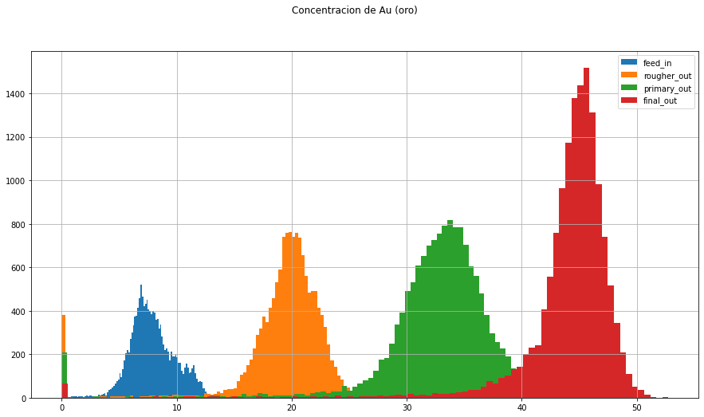

Concentracion de entrada: 7.88

Concentracion despues de la flotación: 19.20

Concentracion despues de la etapa primaria: 32.32

Concentracion final de salida: 43.96

```python
dif_concentracion(data_train['rougher.input.feed_au']
                  ,data_train['rougher.output.concentrate_au']
                  ,data_train['primary_cleaner.output.concentrate_au']
                  ,data_train['final.output.concentrate_au']
                  ,"Au (oro)")
```

Vemos que la concentración de oro en cada fase va aumentando.

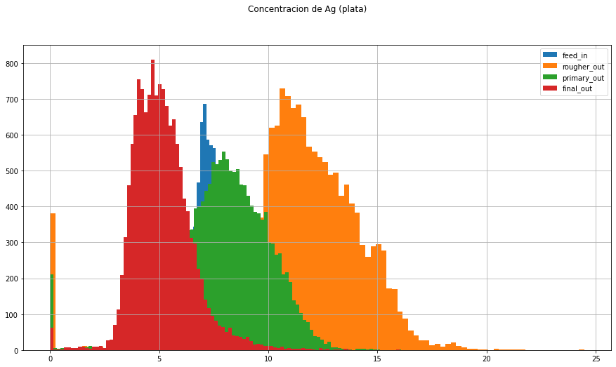

Concentracion de entrada: 8.59

Concentracion despues de la flotación: 11.63

Concentracion despues de la etapa primaria: 8.20

Concentracion final de salida: 5.14

```python
dif_concentracion(data_train['rougher.input.feed_ag']
                  ,data_train['rougher.output.concentrate_ag']
                  ,data_train['primary_cleaner.output.concentrate_ag']
                  ,data_train['final.output.concentrate_ag']
                  ,"Ag (plata)")
```

Vemos que la concentración de plata aumenta luego de la fase de flotación, para luego disminuir en el resto de las etapas.

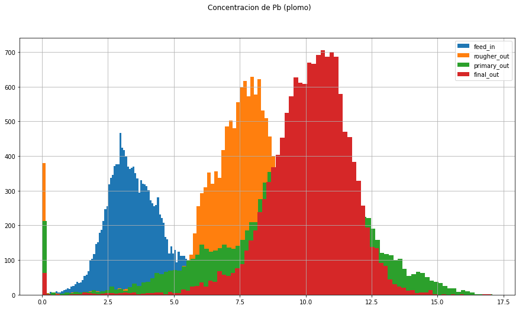

Concentracion de entrada: 3.53

Concentracion despues de la flotación: 7.57

Concentracion despues de la etapa primaria: 9.58

Concentracion final de salida: 10.12

```python
dif_concentracion(data_train['rougher.input.feed_pb']
                  ,data_train['rougher.output.concentrate_pb']
                  ,data_train['primary_cleaner.output.concentrate_pb']
                  ,data_train['final.output.concentrate_pb']
                  ,"Pb (plomo)")
```

Finalmente vemos que la concentración del Plomo aumenta en cada fase.

### Limpieza de valores anormales

En los histogramas anteriores que muestran las concentraciones totales en cada fase, vemos algunos valores anormales cercanos a 0 en la distribución total. Estos valores son pocos en relación a los datos totales, pero pueden afectar el entrenamiento de nuestro modelo, por lo tanto, procederé a eliminarlos.

```python
#Elimino los valores menores que 1 para las concentraciones de Oro
data_train = data_train.drop(data_train[data_train['rougher.input.feed_au']<1].index)
data_train = data_train.drop(data_train[data_train['rougher.output.concentrate_au']<1].index)
data_train = data_train.drop(data_train[data_train['primary_cleaner.output.concentrate_au']<1].index)
data_train = data_train.drop(data_train[data_train['final.output.concentrate_au']<1].index)

#Elimino los valores menores que 1 para las concentraciones de Plata
data_train = data_train.drop(data_train[data_train['rougher.input.feed_ag']<1].index)
data_train = data_train.drop(data_train[data_train['rougher.output.concentrate_ag']<1].index)
data_train = data_train.drop(data_train[data_train['primary_cleaner.output.concentrate_ag']<1].index)
data_train = data_train.drop(data_train[data_train['final.output.concentrate_ag']<1].index)

#Elimino los valores menores que 1 para las concentraciones de Plomo
data_train = data_train.drop(data_train[data_train['rougher.input.feed_pb']<1].index)
data_train = data_train.drop(data_train[data_train['rougher.output.concentrate_pb']<1].index)
data_train = data_train.drop(data_train[data_train['primary_cleaner.output.concentrate_pb']<1].index)
data_train = data_train.drop(data_train[data_train['final.output.concentrate_pb']<1].index)
```

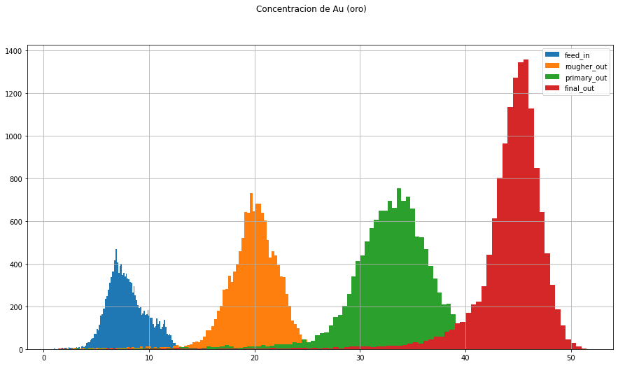

Concentracion de entrada: 7.91

Concentracion despues de la flotación: 19.79

Concentracion despues de la etapa primaria: 32.85

Concentracion final de salida: 44.22

```python
dif_concentracion(data_train['rougher.input.feed_au']
                  ,data_train['rougher.output.concentrate_au']
                  ,data_train['primary_cleaner.output.concentrate_au']
                  ,data_train['final.output.concentrate_au']
                  ,"Au (oro)")
```

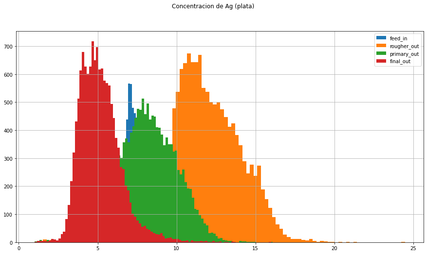

Concentracion de entrada: 8.60

Concentracion despues de la flotación: 11.94

Concentracion despues de la etapa primaria: 8.34

Concentracion final de salida: 5.17

```python
dif_concentracion(data_train['rougher.input.feed_ag']
                  ,data_train['rougher.output.concentrate_ag']
                  ,data_train['primary_cleaner.output.concentrate_ag']
                  ,data_train['final.output.concentrate_ag']
                  ,"Ag (plata)")
```

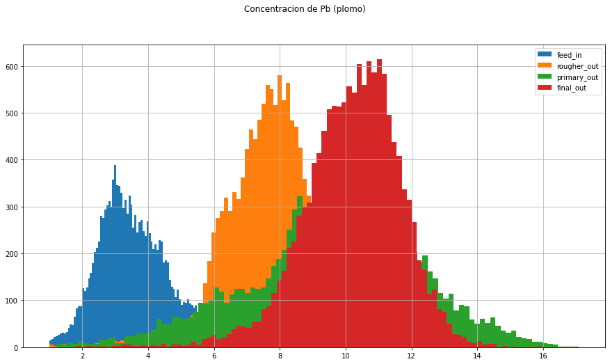

Concentracion de entrada: 3.54

Concentracion despues de la flotación: 7.82

Concentracion despues de la etapa primaria: 9.75

Concentracion final de salida: 10.21

```python
dif_concentracion(data_train['rougher.input.feed_pb']
                  ,data_train['rougher.output.concentrate_pb']
                  ,data_train['primary_cleaner.output.concentrate_pb']
                  ,data_train['final.output.concentrate_pb']
                  ,"Pb (plomo)")
```

Los datos anomalos cercanos a cero fueron eliminados correctamente,

### Distribución del tamaño de las particulas de alimentación

En el dataset que se nos proporcionó, existe una columna que indica el tamaño de las particulas en la entrada (`rougher.input.feed_size`). Sabemos que si la distribución de estas partículas al entrenar el modelo es muy distinta al momento de aplicarlo con nueva data, las predicciones pueden ser erroneas. Por esto compararé la distribución de esta caracteristica entre la data en entrenamiento y la data de prueba.

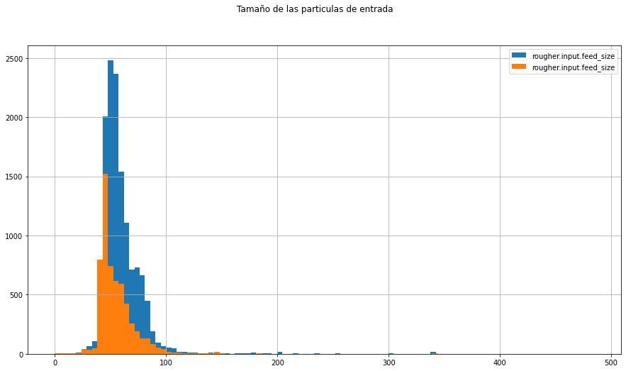

```python
data_train['rougher.input.feed_size'].hist(bins=100,figsize=(15,8))
data_test['rougher.input.feed_size'].hist(bins=100,figsize=(15,8))

plt.suptitle(f'Tamaño de las particulas de entrada')
plt.legend(['rougher.input.feed_size', 'rougher.input.feed_size',])
plt.show()
```

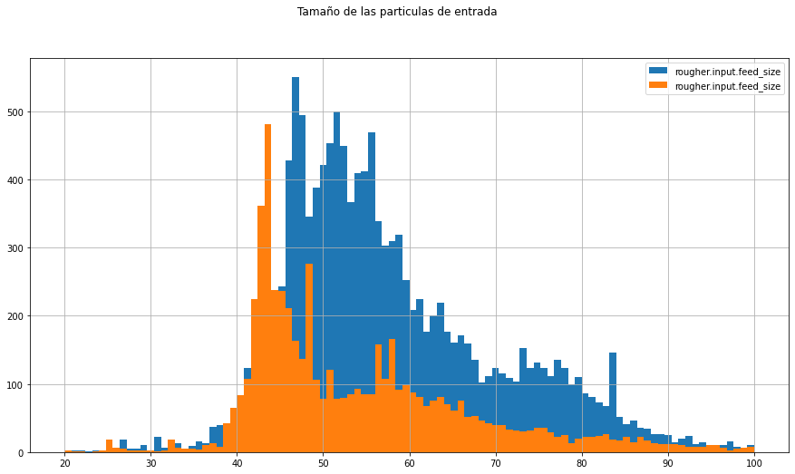

```python
data_train['rougher.input.feed_size'].hist(bins=100,figsize=(15,8),range=(20, 100))
data_test['rougher.input.feed_size'].hist(bins=100,figsize=(15,8),range=(20, 100))

plt.suptitle(f'Tamaño de las particulas de entrada')
plt.legend(['rougher.input.feed_size', 'rougher.input.feed_size',])
plt.show()
```

## Entrenamiento de modelos

Según los requerimentos de la empresa, necesitamos confeccionar dos modelos, uno que sea capaz de predecir la cantidad de concentración de oro a la salida de la flotación (Rougher) y otro que sea capaz de predecir la cantidad de oro final.

### Metrica de evaluación del modelo (sMAPE)

Para poder evaluar el desempeño del modelo se nos solicita utilizar la metrica sMAPE (error medio absoluto porcentual simétrico). Es similar al MAE, pero se expresa en valores relativos en lugar de absolutos. La fórmula para cálcular este valor es la siguiente:

```python
display(Image(url='https://practicum-content.s3.us-west-1.amazonaws.com/resources/moved_smape_1576239058_1589899769.jpg'))
```

[figure not shown]

Pero dado que tenemos dos objetivos (`rougher.output.recovery` y `final.output.recovery`). Necesitamos aplicar una metrica que considere los dos.

```python
display(Image(url='https://practicum-content.s3.us-west-1.amazonaws.com/new-markets/DS_sprint_10/ES/moved_10.3.3ES.png'))
```

[figure not shown]

A continuación crearé una función para poder calcular facilmente el desempeño de nuestros futuros modelos:

```python
def smape_final(y, y_pred):
    # Definimos el número de observaciones de la muestra
    n = len(y)

    # Guardamos los valores absolutos del objetivo, predicciones y de su diferencia para el concentrado rougher
    y_rougher = abs(y.iloc[:, 0])
    y_pred_rougher = abs(y_pred[:, 0])
    diff_rougher = abs(y.iloc[:, 0] - y_pred[:, 0])

    # Guardamos los valores absolutos del objetivo, predicciones y de su diferencia para el concentrado final
    y_final = abs(y.iloc[:, 1])
    y_pred_final = abs(y_pred[:, 1])
    diff_final = abs(y.iloc[:, 1] - y_pred[:, 1])

    # Calculamos el smape para concentrado rougher y final
    smape_rougher = (1/n) * np.sum(diff_rougher / ((y_rougher + y_pred_rougher)/2)) * 100

    smape_final = (1/n) * np.sum(diff_final / ((y_final + y_pred_final)/2)) * 100

    # Calculamos el smape final
    smape_final_score = (0.25*smape_rougher) + (0.75*smape_final)

    return smape_final_score
```

Una vez definida la función que calcula la metrica sMAPE final, procedemos a crear una metrica personalizada, la cual intentaremos maximizar el momento de los entrenamientos de modelos.

```python
smape_score = make_scorer(smape_final, greater_is_better=False)
```

### Entrenamiento de modelos

A continuación entrenaré los modelos para predecir cada fase (Rougher y final) y los evaluaré aplicando validación cruzada. Los objetivos para cada modelo son `rougher.output.recovery` y `final.output.recovery` respectivamente. Dado que el conjunto de entrenamiento posee mas columnas de las que necesitamos, procederé a eliminar todas las columnas que no necesitamos. Para esto, eliminaré todas las columnas que no tenia el dataset de prueba menos las columnas objetivo. Recordar que estas columnas ya las calculamos en un punto anterior y las almacenamos en la lista "diferencia".

#### Preparación final de dataset de entrenamiento

```python
#Remuevo los nombres de las columnas objetivo en la lista "diferencia"
diferencia.remove('rougher.output.recovery')
diferencia.remove('final.output.recovery')

#Remuevo todas las columnas que figuran en la lista "diferencia"
data_train = data_train.drop(diferencia, axis=1)
#Eliminamos los valores ausentes
data_train = data_train.dropna()

data_train.info()
```

```
<class 'pandas.core.frame.DataFrame'>
Int64Index: 12274 entries, 0 to 16859
Data columns (total 55 columns):
 #   Column                                      Non-Null Count  Dtype
---  ------                                      --------------  -----
 0   date                                        12274 non-null  object
 1   final.output.recovery                       12274 non-null  float64
 2   primary_cleaner.input.sulfate               12274 non-null  float64
 3   primary_cleaner.input.depressant            12274 non-null  float64
 4   primary_cleaner.input.feed_size             12274 non-null  float64
 5   primary_cleaner.input.xanthate              12274 non-null  float64
 6   primary_cleaner.state.floatbank8_a_air      12274 non-null  float64
 7   primary_cleaner.state.floatbank8_a_level    12274 non-null  float64
 8   primary_cleaner.state.floatbank8_b_air      12274 non-null  float64
 9   primary_cleaner.state.floatbank8_b_level    12274 non-null  float64
```

[output cut: 47 more lines]

```python
#Definimos caracteristicas y objetivos
features = data_train.drop(['date','rougher.output.recovery','final.output.recovery'], axis=1)
target = data_train[['rougher.output.recovery', 'final.output.recovery']]
```

#### Entrenamiento del modelo

```python
#Establecemos distintos modelos
model_tree = DecisionTreeRegressor()
model_forest = RandomForestRegressor()
model_linear = LinearRegression()

#Establecemos distintos hiperparametros para cada modelo(fase Rougher)
param_grid_tree = {'max_depth': [1, 2, 3, 4, 5, 6, 7, 8, 9, 10]}
param_grid_forest = {'n_estimators': [1, 2, 3, 4, 5, 6, 7, 8, 9, 10], 'max_depth': [1, 2, 3, 4, 5, 6, 7, 8, 9, 10]}
param_grid_linear = {'fit_intercept': [True, False], 'normalize': [True, False]}

#Buscamos los mejores hiperparametros para DecisionTreeRegressor con 3 grupos de validacion (cv=3)
grid_search = GridSearchCV(model_tree, param_grid_tree,scoring=smape_score, cv=3)
grid_search.fit(features, target)
best_params_tree = grid_search.best_params_
best_score_tree = grid_search.best_score_

#Buscamos los mejores hiperparametros para RandomForestRegressor con 3 grupos de validacion (cv=3)
grid_search = GridSearchCV(model_forest, param_grid_forest,scoring=smape_score, cv=3)
grid_search.fit(features, target)
best_params_forest = grid_search.best_params_
best_score_forest = grid_search.best_score_

#Buscamos los mejores hiperparametros para LinearRegression con 3 grupos de validacion (cv=3)
grid_search = GridSearchCV(model_linear, param_grid_linear,scoring=smape_score, cv=3)
grid_search.fit(features, target)
best_params_linear = grid_search.best_params_
best_score_linear = grid_search.best_score_

print_mejorado(f"Mejores hiperparámetros(tree): {best_params_tree}",20)
print_mejorado(f"Mejor puntuación de validación cruzada(tree): {abs(best_score_tree):.3f}", 20)
print("")
print_mejorado(f"Mejores hiperparámetros(forest): {best_params_forest}",20)
print_mejorado(f"Mejor puntuación de validación cruzada(forest): {abs(best_score_forest):.3f}", 20)
print("")
print_mejorado(f"Mejores hiperparámetros(linear): {best_params_linear}",20)
print_mejorado(f"Mejor puntuación de validación cruzada(linear): {abs(best_score_linear):.3f}", 20)
```

Mejores hiperparámetros(tree): {'max_depth': 2}

Mejor puntuación de validación cruzada(tree): 4.056

Mejores hiperparámetros(forest): {'max_depth': 2, 'n_estimators': 2}

Mejor puntuación de validación cruzada(forest): 4.167

Mejores hiperparámetros(linear): {'fit_intercept': True, 'normalize': True}

Mejor puntuación de validación cruzada(linear): 4.595

El mejor modelo para la prediccion de concentración de oro fue el modelo de arbol de decisión (DecisionTreeRegressor) con los hiperparametros: {'max_depth': 2}, el cual obtuvo un valor **sMAPE final de 4.056.**

## Aplicación del modelo con muestra de prueba

Finalmente, una vez identificado el mejor modelo con sus respectivos hiperparametros, lo entrenamos y procedemos a aplicarlo a nuestros conjunto de datos de prueba proporcionados por la empresa. Para esto, agregaré dos columnas adicionales al dataset de prueba con las predicciones de nuestro modelo:

```python
model=DecisionTreeRegressor(max_depth=2)
model.fit(features, target)
```

```
DecisionTreeRegressor(max_depth=2)
```

```python
data_test = data_test.dropna()
data_test_aux = data_test.drop(['date'], axis=1)

#Agregamos nuevas columnas con las predicciones a la muestra de prueba
data_test['rougher.output.recovery.predict'] = model.predict(data_test_aux)[:, 0]
data_test['final.output.recovery.predict'] = model.predict(data_test_aux)[:, 1]
```

```python
data_test.info()
```

```
<class 'pandas.core.frame.DataFrame'>
Int64Index: 5383 entries, 0 to 5855
Data columns (total 55 columns):
 #   Column                                      Non-Null Count  Dtype
---  ------                                      --------------  -----
 0   date                                        5383 non-null   object
 1   primary_cleaner.input.sulfate               5383 non-null   float64
 2   primary_cleaner.input.depressant            5383 non-null   float64
 3   primary_cleaner.input.feed_size             5383 non-null   float64
 4   primary_cleaner.input.xanthate              5383 non-null   float64
 5   primary_cleaner.state.floatbank8_a_air      5383 non-null   float64
 6   primary_cleaner.state.floatbank8_a_level    5383 non-null   float64
 7   primary_cleaner.state.floatbank8_b_air      5383 non-null   float64
 8   primary_cleaner.state.floatbank8_b_level    5383 non-null   float64
 9   primary_cleaner.state.floatbank8_c_air      5383 non-null   float64
```

[output cut: 47 more lines]

```python
data_test[['date','rougher.output.recovery.predict','final.output.recovery.predict']].head(20)
```

|  | date | rougher.output.recovery.predict | final.output.recovery.predict |
| --- | --- | --- | --- |
| 0 | 2016-09-01 00:59:59 | 84.880397 | 90.226647 |
| 1 | 2016-09-01 01:59:59 | 84.880397 | 90.226647 |
| 2 | 2016-09-01 02:59:59 | 84.880397 | 90.226647 |
| 3 | 2016-09-01 03:59:59 | 84.880397 | 90.226647 |
| 4 | 2016-09-01 04:59:59 | 84.880397 | 90.226647 |
| 5 | 2016-09-01 05:59:59 | 84.880397 | 90.226647 |
| 6 | 2016-09-01 06:59:59 | 84.880397 | 90.226647 |
| 7 | 2016-09-01 07:59:59 | 78.157992 | 91.555130 |
| 8 | 2016-09-01 08:59:59 | 78.157992 | 91.555130 |
| 9 | 2016-09-01 09:59:59 | 78.157992 | 91.555130 |
| 10 | 2016-09-01 10:59:59 | 78.157992 | 91.555130 |
| 11 | 2016-09-01 11:59:59 | 78.157992 | 91.555130 |
| 12 | 2016-09-01 12:59:59 | 78.157992 | 91.555130 |
| 13 | 2016-09-01 13:59:59 | 78.157992 | 91.555130 |
| 14 | 2016-09-01 14:59:59 | 78.157992 | 91.555130 |
| 15 | 2016-09-01 15:59:59 | 78.157992 | 91.555130 |
| 16 | 2016-09-01 16:59:59 | 84.880397 | 90.226647 |
| 17 | 2016-09-01 17:59:59 | 84.880397 | 90.226647 |
| 18 | 2016-09-01 18:59:59 | 84.880397 | 90.226647 |
| 19 | 2016-09-01 19:59:59 | 78.157992 | 91.555130 |